# Generate simulated spatial transcriptomic dataset from STARmap dataset

Ningshan Li & Yunqing Liu

2023/01/25

# 1 Version

```r
version[['version.string']]
```

```
[1] "R version 4.2.2 Patched (2022-11-10 r83330)"
```

# 2 Load manually cruated STARmap dataset

This **single-cell resolution** spatial transcriptomics dataset contains two independent experiments on **mouse primary visual cortex** ( [publication](https://www.science.org/doi/10.1126/science.aat5691)), and both experiments are included in our analysis. The physical locations and gene expression profiles (raw nUMIs) of the selected cells are manually curated and saved into a R object [`CoarseGrain_Data.rds`](https://github.com/az7jh2/SDePER_Analysis/blob/main/Simulation/Generate_simulation_data/CoarseGrain_Data.rds). After loading data, it’s a list containing the meta data (in slot `meta`) and gene raw nUMI (in slot `count`)

```r
file_name = file.path(home.dir, 'CoarseGrain_Data.rds')
org_data = readRDS(file_name)
meta_data = org_data$meta
gene_count = org_data$count
rm(org_data)
print(sprintf('load data from %s', file_name))
```

```
[1] "load data from /home/hill103/Documents/SharedFolder/ToHost/CVAE-GLRM_Analysis/Simulation/Generate_simulation_data/CoarseGrain_Data.rds"
```

```r
# first 12 gene names need to exclude the first Character "X"
for (i in 1:12) {
  colnames(gene_count)[i] = substr(colnames(gene_count)[i], 2, nchar(colnames(gene_count)[i]))
}
```

We only include **2,002 cells** across **12 cell types** which overlaps with the paired reference scRNA-seq dataset. **No further filtering on genes or cells**!

```r
print(sprintf('total %d cells, %d genes', nrow(gene_count), ncol(gene_count)))
```

```
[1] "total 2002 cells, 1020 genes"
```

```r
gene_count[1:5, 1:5]
```

|  | 1110008F13Rik | 1110008P14Rik | 1700019D03Rik | 1700086L19Rik | 2810468N07Rik |
| --- | --- | --- | --- | --- | --- |
| Dat1_Cell_00008 | 1 | 2 | 0 | 0 | 0 |
| Dat1_Cell_00009 | 0 | 0 | 0 | 1 | 1 |
| Dat1_Cell_00012 | 1 | 0 | 0 | 2 | 0 |
| Dat1_Cell_00014 | 0 | 0 | 0 | 0 | 0 |
| Dat1_Cell_00015 | 0 | 2 | 0 | 1 | 0 |

Columns in meta data:

- `index`: cell barcode
- `dat`: 1 or 2, indicating cell is from 1st or 2nd experiment
- `cluster_name`: cell type annotation
- `X`, `Y`: physical locations (in pixels) of cells. We manually add a **4500 pixels offset** on `X` coordinate of cells from 1st experiment

Number of cells of each select cell type is shown as below

```r
stopifnot(all(meta_data$index == row.names(gene_count)))

table(as.character(meta_data$cluster_name))
```

```
Astro eL2/3   eL4   eL5   eL6  Endo Micro Oligo PVALB   Smc   SST   VIP
  259   292   327   110   368   134    69   278    61    42    33    29
```

# 3 Generate squre pseudo-spots by *coarse-graining*

We defined a square with **500×500** pixels (**~51.5 μm**) as one pseudo-spot, and all cells falling into this square area are considered as cells in this pseudo-spot.

In total we get **581** square pseudo-spots, and each square pseudo-spot contains 1 to at most 12 cells (at most 6 different cell types)

The nUMI count of gene $j$ for a given pseudo-spot consisting of cells $i=1,…,n$ are defined as:
$$nUMI_j=\frac{∑_i^n (x_{ij}/N_i)} {n}
)×1,000$$
where $x_ij$ is nUMI of gene $j$ for cell $i$ and $N_i$ is the sequencing depth (sum of nUMI of all genes) of cell $i$.

```r
#dat:meta.data for cell-level spatial data; count:data.frame of count data for cell-level spatial data
create_grid<-function(dat,count,x="X",y="Y",index="index",cluster="louvain",breaks=200){
    seq_depth<-rowSums(count)
    if(is.factor(dat[,cluster])){dat[,cluster]<-factor(dat[,cluster])}
    range_x<-range(dat[,x])
    range_y<-range(dat[,y])
    x_start<-floor(range_x[1])
    x_end<-ceiling(range_x[2])
    grid_x<-seq(x_start,x_end,breaks)
    y_start<-floor(range_y[1])
    y_end<-ceiling(range_y[2])
    grid_y<-seq(y_start,y_end,breaks)
    grid_table<-ct_table<-data.frame(ncell=numeric(),x=numeric(),y=numeric())
    #grid_table<-matrix(0,nrow=length(grid_y),ncol=length(grid_x))
    ct_table<-grid_table
    spot_exp<-list()
    #rownames(grid_table)<-grid_y
    #colnames(grid_table)<-grid_x
    if(max(grid_x)<x_end){grid_x<-c(grid_x,max(grid_x)+breaks)}
    if(max(grid_y)<y_end){grid_y<-c(grid_y,max(grid_y)+breaks)}
    ncell_fov<-nrow(dat)
    for(i in 1:(length(grid_y)-1)){
        for(j in 1:(length(grid_x)-1)){
            fall_id<-which(dat[,x]>=grid_x[j] & dat[,x]<grid_x[j+1] & dat[,y]>=grid_y[i] & dat[,y]<grid_y[i+1])
            grid_table<-rbind(grid_table,c(ncell=length(fall_id),x=grid_x[j],y=grid_y[i]))
            ct_table<-rbind(ct_table,c(nct=length(unique(dat[fall_id,cluster])),x=grid_x[j],y=grid_y[i]))
            spot_exp<-c(spot_exp,list(ceiling(colSums(count[dat[fall_id,index],]/(seq_depth[dat[fall_id,index]]*length(fall_id))*scaler))))
            names(spot_exp)[length(spot_exp)]<-paste0("x",grid_x[j],"y",grid_y[i])
            tmp_prop<-data.frame(cbind(t(as.matrix(table(dat[fall_id,cluster])/sum(table(dat[fall_id,cluster])),nrow=1,drop=F)),x=grid_x[j],y=grid_y[i]))
            if(i==1&j==1){grid_prop=tmp_prop}else(grid_prop=rbind(grid_prop,tmp_prop))
        }
    }
    colnames(grid_table)<-c("ncell","x","y")
    colnames(ct_table)<-c("nct","x","y")
    spot_exp_mat<-Reduce(cbind,spot_exp)
    colnames(spot_exp_mat)<-names(spot_exp)
    nonempty_cell<-which(grid_table$ncell!=0)
    grid_table=grid_table[nonempty_cell,]
    ct_table=ct_table[nonempty_cell,]
    grid_prop=grid_prop[nonempty_cell,]
    spot_exp_mat=spot_exp_mat[,nonempty_cell]
    return(list(ncell_grid=grid_table,nct_grid=ct_table,prop_grid=grid_prop,spatial_exp=spot_exp_mat))
}

# spatial_exp is the generated coarse graining expression data
scaler=1000
grid_l=500
starmap_res = create_grid(meta_data, gene_count, cluster="cluster_name", breaks=grid_l)
```

Locations of cells with grid showing the square pseudo-spots

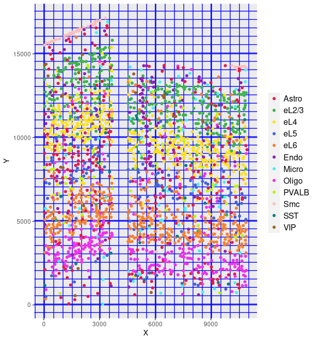

```r
ggplot(meta_data, aes(x=X, y=Y, color=cluster_name)) +
  geom_point() +
  scale_color_manual(values=my.distinct.colors20) +
  scale_x_continuous(minor_breaks=seq(min(meta_data$X)-grid_l, max(meta_data$X)+grid_l, grid_l)) +
  scale_y_continuous(minor_breaks=seq(min(meta_data$Y)-grid_l, max(meta_data$Y)+grid_l, grid_l)) +
  theme_gray() +
  theme(legend.title=element_blank(), legend.text=element_text(size=12),
        panel.grid.major = element_line(size = 0.5, linetype = 'solid', colour = "blue"),
        panel.grid.minor = element_line(size = 0.5, linetype = 'solid', colour = "blue"))
```

Pie chart of cell type proportions of square pseudo-spots

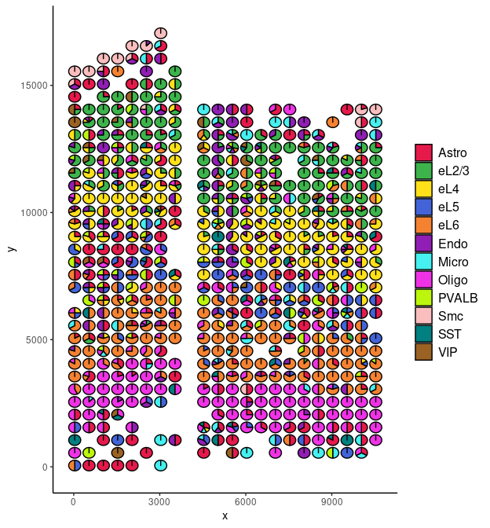

```r
# rename cell type eL2.3 to eL2/3
colnames(starmap_res$prop_grid)[2] = "eL2/3"

ggplot() +
  geom_scatterpie(aes(x=x, y=y), data=starmap_res$prop_grid, cols=colnames(starmap_res$prop_grid)[1:12]) +
  scale_fill_manual(values=my.distinct.colors20) +
  theme_classic() +
  theme(legend.title=element_blank(), legend.text=element_text(size=12))
```

# 4 Prepare Adjacency Matrix

We define the neighborhood of a square pseudo-spot contains the adjacent **left**, **right**, **top** and **bottom** pseudo-spot, that is, one pseudo-spot has at most 4 neighbors.

The physical location (in pixels) of pseudo-spots are saved in the column `x` and `y` in dataframe `starmap_res$prop_grid`, we extract them and store into a dataframe named `local_df`

The generated Adjacency Matrix `A` only contains **1** and **0**, where 1 represents corresponding two pseudo-spots are adjacent spots according to the definition of neighborhood, while value 0 for non-adjacent pseudo-spots. Note **all diagonal entries are 0s**.

```r
# generate spot location dataframe
local_df = starmap_res$prop_grid[, c('x', 'y')]
row.names(local_df) = paste0('x', local_df$x, 'y', local_df$y)
colnames(local_df) = c('imagecol', 'imagerow')


getNeighbour = function(array_row, array_col) {
  # based on the (row, col) of one spot, return the (row, col) of all 6 neighbours
  return(list(c(array_row-500, array_col),
              c(array_row+500, array_col),
              c(array_row+0, array_col-500),
              c(array_row+0, array_col+500)))
}


# adjacency matrix
A = matrix(0, nrow = nrow(local_df), ncol = nrow(local_df))
row.names(A) = rownames(local_df)
colnames(A) = rownames(local_df)

for (i in 1:nrow(local_df)) {
  barcode = rownames(local_df)[i]
  array_row = local_df[i, 'imagerow']
  array_col = local_df[i, 'imagecol']

  # get neighbors
  neighbours = getNeighbour(array_row, array_col)

  # fill the adjacency matrix
  for (this.vec in neighbours) {
    tmp.p = rownames(local_df[local_df$imagerow==this.vec[1] & local_df$imagecol==this.vec[2], ])

    if (length(tmp.p) >= 1) {
      # target spots have neighbors in selected spots
      for (neigh.barcode in tmp.p) {
        A[barcode, neigh.barcode] = 1
      }
    }
  }
}
```

Plot Adjacency Matrix. Each node is a pseudo-spot, pseudo-spots within neighborhood are connected with edges.

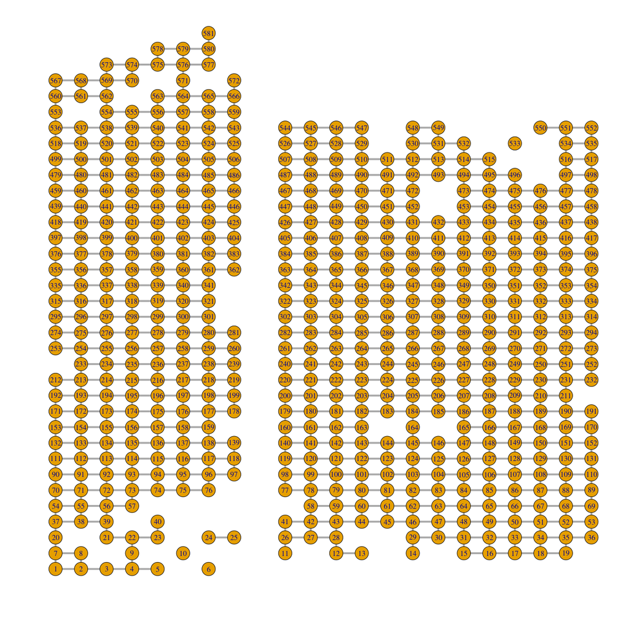

```r
g = graph_from_adjacency_matrix(A, 'undirected', add.colnames = NA, add.rownames = NA)
# manually set nodes x and y coordinates
vertex_attr(g, name = 'x') = local_df$imagecol
vertex_attr(g, name = 'y') = local_df$imagerow
plot(g, vertex.size=5, edge.width=4, margin=-0.05)
```

# 5 Save generated simulated spatial dataset

## 5.1 Save nUMI counts of all genes of spatial pseudo-spots

nUMI count of all genes are stored in `starmap_res$spatial_exp`, and rows as genes, columns as pseudo-spots. We transpose this matrix into **rows as pseudo-spots and columns as genes**, then save into file [`sim_spatial_spot_nUMI.csv`](https://github.com/az7jh2/SDePER_Analysis/blob/main/Simulation/Generate_simulation_data/sim_spatial_spot_nUMI.csv)

```r
to_save = t(starmap_res$spatial_exp)
to_save[1:5, 1:5]
```

```
         1110008F13Rik 1110008P14Rik 1700019D03Rik 1700086L19Rik 2810468N07Rik
x34y50               1             0             4             6             0
x534y50              0             0             4             0             2
x1034y50             0             0             0             0             0
x1534y50             0             0             0             0             0
x2034y50             2             3             0             0             0
```

```r
write.csv(to_save, 'sim_spatial_spot_nUMI.csv')
print(sprintf('save %d gene nUMIs of %d simulated spatial pseudo-spots into file %s', ncol(to_save), nrow(to_save), 'sim_spatial_spot_nUMI.csv'))
```

```
[1] "save 1020 gene nUMIs of 581 simulated spatial pseudo-spots into file sim_spatial_spot_nUMI.csv"
```

## 5.2 Save Physical Locations of spatial pseudo-spots

physical locations of all pseudo-spots are stored in `local_df`, and saved into file [`sim_spatial_spot_loc.csv`](https://github.com/az7jh2/SDePER_Analysis/blob/main/Simulation/Generate_simulation_data/sim_spatial_spot_loc.csv)

```r
local_df$x = floor(local_df$imagecol/500) + 1
local_df$y = floor(local_df$imagerow/500) + 1
local_df[1:5, ]
```

|  | imagecol | imagerow | x | y |
| --- | --- | --- | --- | --- |
| x34y50 | 34 | 50 | 1 | 1 |
| x534y50 | 534 | 50 | 2 | 1 |
| x1034y50 | 1034 | 50 | 3 | 1 |
| x1534y50 | 1534 | 50 | 4 | 1 |
| x2034y50 | 2034 | 50 | 5 | 1 |

```r
write.csv(local_df, 'sim_spatial_spot_loc.csv')
print(sprintf('save Physical Locations of simulated spatial pseudo-spots into file %s', 'sim_spatial_spot_loc.csv'))
```

```
[1] "save Physical Locations of simulated spatial pseudo-spots into file sim_spatial_spot_loc.csv"
```

## 5.3 Save Adjacency Matrix of spatial pseudo-spots

Adjacency Matrix are stored in `A`, and saved into file [`sim_spatial_spot_adjacency_matrix.csv`](https://github.com/az7jh2/SDePER_Analysis/blob/main/Simulation/Generate_simulation_data/sim_spatial_spot_adjacency_matrix.csv)

```r
A[1:5, 1:5]
```

```
         x34y50 x534y50 x1034y50 x1534y50 x2034y50
x34y50        0       1        0        0        0
x534y50       1       0        1        0        0
x1034y50      0       1        0        1        0
x1534y50      0       0        1        0        1
x2034y50      0       0        0        1        0
```

```r
write.csv(A, 'sim_spatial_spot_adjacency_matrix.csv')
print(sprintf('save Adjacency Matrix of simulated spatial pseudo-spots into file %s', 'sim_spatial_spot_adjacency_matrix.csv'))
```

```
[1] "save Adjacency Matrix of simulated spatial pseudo-spots into file sim_spatial_spot_adjacency_matrix.csv"
```

## 5.4 Save True cell type proportions of spatial pseudo-spots

True cell type proportions of simulated spatial pseudo-spots are stored in `starmap_res$prop_grid`, and saved into file [`sim_spatial_spot_true_prop.csv`](https://github.com/az7jh2/SDePER_Analysis/blob/main/Simulation/Generate_simulation_data/sim_spatial_spot_true_prop.csv)

```r
to_save = starmap_res$prop_grid
row.names(to_save) = paste0('x', to_save$x, 'y', to_save$y)
to_save = to_save[, !(colnames(to_save) %in% c('x', 'y'))]
to_save[1:5,]
```

|  | Astro | eL2/3 | eL4 | eL5 | eL6 | Endo | Micro | Oligo | PVALB | Smc | SST | VIP |
| --- | --- | --- | --- | --- | --- | --- | --- | --- | --- | --- | --- | --- |
| x34y50 | 0 | 0 | 0 | 0.5 | 0.5 | 0 | 0 | 0 | 0 | 0 | 0 | 0 |
| x534y50 | 1 | 0 | 0 | 0.0 | 0.0 | 0 | 0 | 0 | 0 | 0 | 0 | 0 |
| x1034y50 | 1 | 0 | 0 | 0.0 | 0.0 | 0 | 0 | 0 | 0 | 0 | 0 | 0 |
| x1534y50 | 1 | 0 | 0 | 0.0 | 0.0 | 0 | 0 | 0 | 0 | 0 | 0 | 0 |
| x2034y50 | 1 | 0 | 0 | 0.0 | 0.0 | 0 | 0 | 0 | 0 | 0 | 0 | 0 |

```r
write.csv(to_save, 'sim_spatial_spot_true_prop.csv')
print(sprintf('save True cell type proportions of simulated spatial pseudo-spots into file %s', 'sim_spatial_spot_true_prop.csv'))
```

```
[1] "save True cell type proportions of simulated spatial pseudo-spots into file sim_spatial_spot_true_prop.csv"
```

## 5.5 Save nUMI counts of STARmap cells

nUMI count of all cells in STARmap dataset are stored in `gene_count` with **rows as cells and columns as genes**, and saved into file [`STARmap_cell_nUMI.csv`](https://github.com/az7jh2/SDePER_Analysis/blob/main/Simulation/Run_SDePER_on_simulation_data/Scenario_1/ref_spatial/STARmap_cell_nUMI.csv)

```r
gene_count[1:5, 1:5]
```

|  | 1110008F13Rik | 1110008P14Rik | 1700019D03Rik | 1700086L19Rik | 2810468N07Rik |
| --- | --- | --- | --- | --- | --- |
| Dat1_Cell_00008 | 1 | 2 | 0 | 0 | 0 |
| Dat1_Cell_00009 | 0 | 0 | 0 | 1 | 1 |
| Dat1_Cell_00012 | 1 | 0 | 0 | 2 | 0 |
| Dat1_Cell_00014 | 0 | 0 | 0 | 0 | 0 |
| Dat1_Cell_00015 | 0 | 2 | 0 | 1 | 0 |

```r
write.csv(gene_count, 'STARmap_cell_nUMI.csv')
print(sprintf('save %d gene nUMIs of %d STARmap cells into file %s', ncol(gene_count), nrow(gene_count), 'STARmap_cell_nUMI.csv'))
```

```
[1] "save 1020 gene nUMIs of 2002 STARmap cells into file STARmap_cell_nUMI.csv"
```

## 5.6 Save cell type annotation of STARmap cells

Cell type annotation of all cells in STARmap dataset are stored in `meta_data$cluster_name`, and saved into file [`STARmap_cell_celltype.csv`](https://github.com/az7jh2/SDePER_Analysis/blob/main/Simulation/Run_SDePER_on_simulation_data/Scenario_1/ref_spatial/STARmap_cell_celltype.csv)

```r
to_save = meta_data['cluster_name']
row.names(to_save) = meta_data$index
colnames(to_save) = 'celltype'
to_save$celltype = as.character(to_save$celltype)
to_save[1:5, , drop=F]
```

|  | celltype |
| --- | --- |
| Dat1_Cell_00008 | eL6 |
| Dat1_Cell_00009 | eL4 |
| Dat1_Cell_00012 | eL2/3 |
| Dat1_Cell_00014 | eL6 |
| Dat1_Cell_00015 | eL5 |

```r
write.csv(to_save, 'STARmap_cell_celltype.csv')
print(sprintf('save cell type annotation of STARmap cells into file %s', 'STARmap_cell_celltype.csv'))
```

```
[1] "save cell type annotation of STARmap cells into file STARmap_cell_celltype.csv"
```